# XTern 2020

## Getting packages

The packages that are gonna be used are tidyverse, leaflet, geosphere, ggplot2, and tidy text, which will assist in cleaning, processing and modeling the data, creating graphs and interactive map, and text mining.

```r
#install.packages('tidyverse')
#install.packages('leaflet')
#install.packages('geosphere')
#install.packages('ggplot2')
#install.packages('tidytext')
library(tidyverse)
library(leaflet)
library(geosphere)
library(ggplot2)
library(tidytext)
```

## Getting and cleaning data

There are some restaurants that do not have ratings and reviews, either because they just open or there is insufficient information. Those cells will be replaced by N/A and the Ratings and Reviews columns are also converted to numeric for easier work.

```r
restaurant_data <- read.csv(file='~/Desktop/2020-XTern-DS.csv', header=TRUE, sep=',')
restaurant_data$Rating <- str_replace(restaurant_data$Rating, 'NEW', NA_character_)
restaurant_data$Rating <- str_replace(restaurant_data$Rating, '-', NA_character_)
restaurant_data$Reviews <- str_replace(restaurant_data$Reviews, '-', NA_character_)
restaurant_data$Rating <- as.numeric((restaurant_data$Rating))
restaurant_data$Reviews <- as.numeric((restaurant_data$Reviews))
```

## 1. Top 20 Most Popular Restaurants:

The scoring algorithm used to rank the restaurants takes into account the ratings and number of reviews of each restaurant and uses the True Bayesian Estimate method. This method will account for situations such as when a restaurant has a high rating but very few number of reviews, which will not be as reliable as a restaurant having a lower rating but a lot of reviews. The method uses the formula:

weighted rating (WR) = (v ÷ (v+m)) × R + (m ÷ (v+m)) × C where:

R = Rating

v = number of reviews

m = minimum reviews required

C = the mean rating across the whole report

I will choose the minimum reviews required as 20 which is reasonable for a restaurant. Cells with N/A value will not be considered in the calculation.

```r
C <- mean(restaurant_data$Rating, na.rm=TRUE)
m <- 20
w <- restaurant_data$Reviews/(restaurant_data$Reviews + m)
restaurant_data$Score <- w*restaurant_data$Rating + (1-w)*C
x = restaurant_data[order(restaurant_data$Score, decreasing= T),]
top20 <- head(x, 20)
top20$Restaurant
```

```
##  [1] ID_4728 ID_7412 ID_1064 ID_2051 ID_7924 ID_1160 ID_6537 ID_383  ID_6278
## [10] ID_1666 ID_6915 ID_7678 ID_7739 ID_7433 ID_1350 ID_7858 ID_4365 ID_6967
## [19] ID_7158 ID_2421
## 1807 Levels: ID_1000 ID_1004 ID_1005 ID_1007 ID_1013 ID_1015 ID_1016 ... ID_996
```

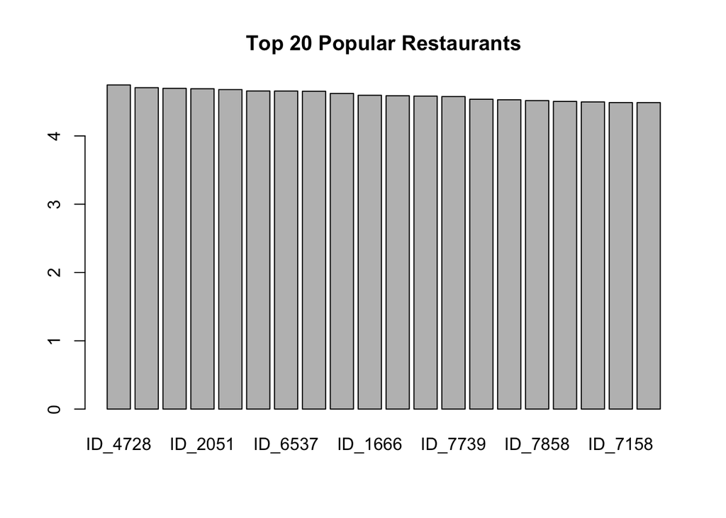

```r
barplot(top20$Score, main="Top 20 Popular Restaurants", names.arg=as.character(top20$Restaurant))
```

Top 20 Restaurant IDs are shown together with a barplot of their weighted score.

## 2. Clustering Locations:

Restaurants are clustered into 10 clusters using kmeans clustering method and based on their longitude and latitude data. The graph shows the clusters in different colors.

```r
cdat <- data.frame(restaurant_data$Latitude, restaurant_data$Longitude)
clusters <- kmeans(cdat, 10)
clusters
```

```
## K-means clustering with 10 clusters of sizes 186, 187, 212, 223, 245, 167, 216, 188, 217, 178
##
## Cluster means:
##    restaurant_data.Latitude restaurant_data.Longitude
## 1                  39.87468                 -85.56657
## 2                  39.36631                 -85.51217
## 3                  39.16653                 -85.16508
## 4                  39.83415                 -85.16885
## 5                  39.50780                 -85.82632
## 6                  39.11465                 -85.51662
## 7                  39.17582                 -85.84268
## 8                  39.82882                 -85.85576
## 9                  39.48576                 -85.14864
## 10                 39.63187                 -85.44308
##
```

[output cut: 96 more lines]

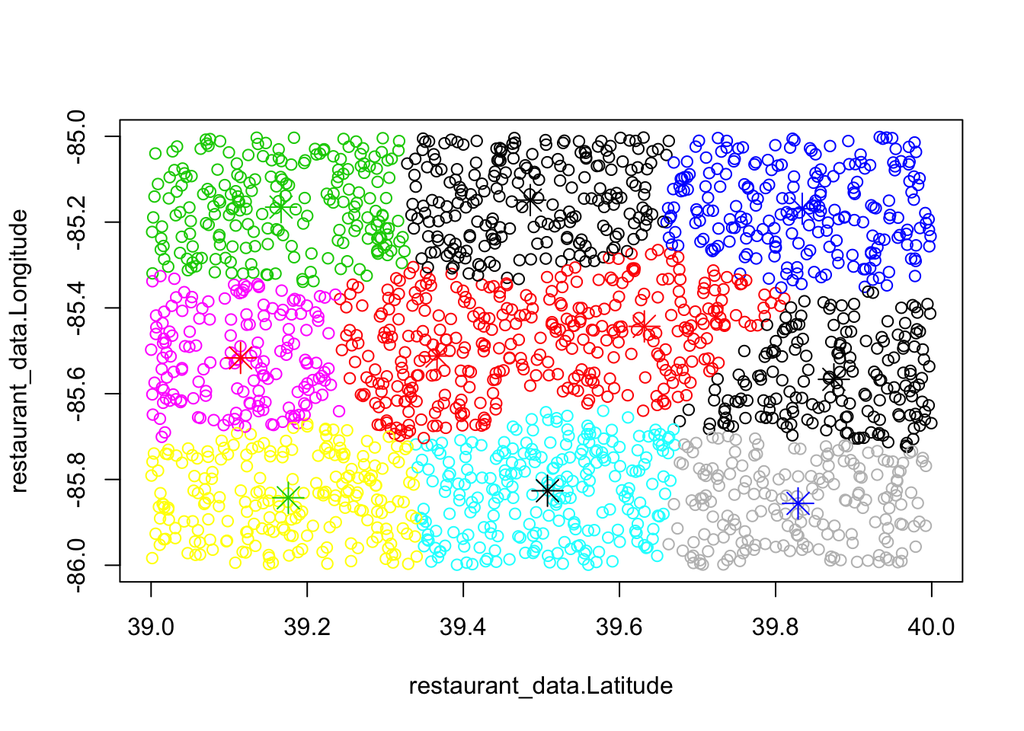

```r
plot(cdat, col = clusters$cluster)
points(clusters$centers, col = 1:4, pch = 8, cex = 2)
```

```r
cluster_center <- data.frame(clusters$centers)
```

## 3. Interactive Map:

An interactive map is created with each restaurant as a circle marker on the map based on their location, and the color of the circle marker is based on their weighted score with information in the legend on the right of the map. Restaurants with N/A value for their score will have grey circle markers. The clusters are also shown on the map using the centroid as the center and a radius of 15000. Top 20 popular restaurants are represented by the marker and when clicking on the marker their ID will be shown.

```r
pal = colorNumeric("YlOrRd", domain = restaurant_data$Score)
int_map <- leaflet(restaurant_data)%>%
  addProviderTiles(providers$OpenStreetMap.Mapnik)%>%
  addCircleMarkers(lng=restaurant_data$Longitude, lat=restaurant_data$Latitude, col = ~pal(restaurant_data$Score), opacity = 1.1, radius = 0.3, popup=restaurant_data$Restaurant)%>%
  addCircles(lng=cluster_center$restaurant_data.Longitude, lat=cluster_center$restaurant_data.Latitude, radius = 15000)%>%
  addMarkers(lng=top20$Longitude, lat=top20$Latitude, popup = top20$Restaurant)%>%
  addLegend(pal = pal, values = ~restaurant_data$Score, title = 'Restaurant Weighted Score')
int_map
```

[interactive chart not shown]

## 4. Most Popular Cuisines:

Using text mining, the cuisines of each restaurant are seprated and the graph shows the top 10 most popular cuisines with the number of restaurants serving them.

```r
attach(restaurant_data)
popular_cuisine   <- restaurant_data %>%
  dplyr::select(Restaurant, Cuisines)%>%
  mutate(Cuisines = as.character(restaurant_data$Cuisines)) %>%
  unnest_tokens(Cuisine, Cuisines, token = 'regex', pattern=",") %>%
  unique() %>%
  group_by(trimws(Cuisine)) %>%
  summarise(Number_of_Restaurant = n()) %>%
  arrange(desc(Number_of_Restaurant)) %>%
  top_n(10)
```

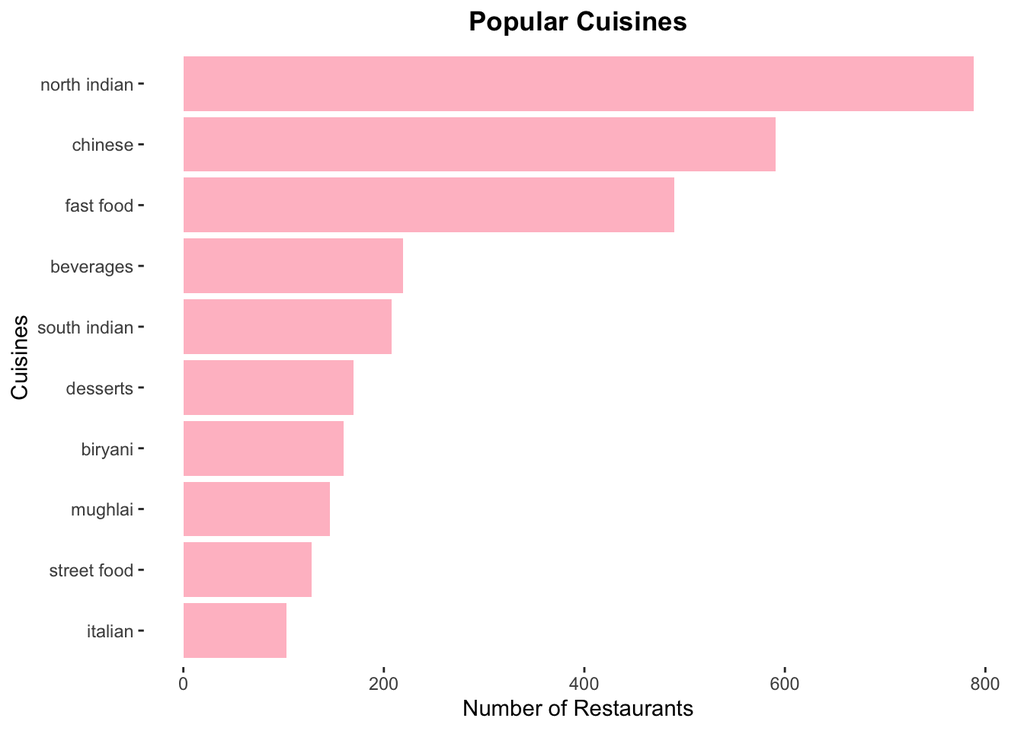

```r
names(popular_cuisine)[1] <- 'Cuisine'
Popular_Cuisine_Plot <- ggplot(popular_cuisine, aes(x = reorder(Cuisine, Number_of_Restaurant), y = Number_of_Restaurant)) +
  geom_bar(stat = 'identity', fill='pink') +
  coord_flip() + theme(panel.background = element_blank(), strip.background = element_blank(),
                       plot.title = element_text(hjust = 0.5, face = 'bold',color = 'black')) +
  labs(x = 'Cuisines', y = 'Number of Restaurants', title = "Popular Cuisines")
Popular_Cuisine_Plot
```